# ProblemSet4

Question 1

Link to equipment data https://fred.stlouisfed.org/series/Y033RG3Q086SBEA.  
Link to non-durables data https://fred.stlouisfed.org/series/DNDGRG3Q086SBEA

```python
%matplotlib inline
import numpy
from statsmodels.tsa.filters.hp_filter import hpfilter
import pandas
import matplotlib.pyplot as plt
#downloading datset
equipment=pandas.DataFrame.from_csv("equip_invest.csv")
nondur=pandas.DataFrame.from_csv("non_dur_goods.csv")
#making relative price series
rel_price=equipment["Y033RG3Q086SBEA"]/nondur["DNDGRG3Q086SBEA"]
#taking lod
log_rel_price=numpy.log(rel_price)
#hp-filtering and convertive to better format
hp_rel_price=hpfilter(log_rel_price, lamb=1600)
hp_rel_price=pandas.Series(hp_rel_price[1])
#getting_busines cycle component
bus_cyc=log_rel_price-hp_rel_price
```

Plot hp-filtered (orange) and actual series (blue) and business cycle component (green).

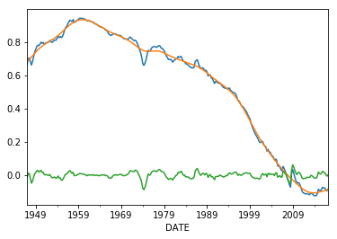

```python
ax = log_rel_price.plot()
hp_rel_price.plot(ax=ax)
bus_cyc.plot()
```

Estimating AR(1) proces

```python
from statsmodels.tsa.ar_model import AR
ar = AR(bus_cyc)
model_fit=ar.fit(maxlag=1)
BCstd=numpy.std(bus_cyc)
print('Coefficients: %s' % model_fit.params)
print('Standard deviation of the business cycle: %s' % BCstd)
```

```
Coefficients: const    0.000052
L1.y     0.817924
dtype: float64
Standard deviation of the business cycle: 0.01858950350435559
```

The estimated AR(1) coefficient is 0.817924 and constant is approximately 0. For a model $y_t=a+by_{t-1}+\epsilon_t$, variance is: $\sigma_{y}^{2}=b^2 \sigma_{y}^{2}+\sigma_{\epsilon}^2$ As a result to find the variance of disturbance term $\epsilon$ given the variance of the process one can use the following formula: $\sigma_{\epsilon}^2=(1-b^2)\sigma_{y}^2$

Approximating the series with Tauchen method, using R package RTauchen to calculate transition matrix and importing it from a csv file

```python
import math
import csv
autocorr=0.817924
sigma=BCstd
n=7
m=3
sigma_2 = sigma*(math.sqrt(1-autocorr**2))
print(sigma_2)
#Importing the transition matrix from the file
reader = csv.reader(open("tauchen.csv", "r"), delimiter=",")
x = list(reader)
tauchen_matr = numpy.array(x).astype("float")
#getting the nodes
def Tauchen(n,m, sigma, autocorr):
#Sigma_2 is the standard deviation of the disturbance term
#calculated from the standard deviation of the process
    sigma_2 = sigma*(math.sqrt(1-autocorr**2))
    z_upper = m*sigma_2
    z_lower = -m*sigma_2
    z = []
    for i in range(1,n+1):
        z_i = z_lower + (z_upper - z_lower)*(i - 1)/(n-1)
        z.append(z_i)
    return(z)
#tauchen stores vector of nodes
tauchen=Tauchen(n,m, sigma, autocorr)
print(tauchen)
```

```
0.010695029926728373
[-0.03208508978018512, -0.021390059853456746, -0.010695029926728373, 0.0, 0.010695029926728376, 0.021390059853456746, 0.03208508978018512]
```

The initial value is -0.012385. The closest state to this value is state 2, numbering states from 0 to 6, so I will choose the initial state 2. Number of iterations is 282, as this is the length of my time series.

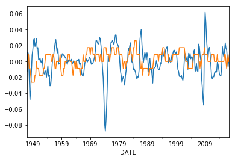

```python
def simulator(tauchen,tauchen_matr,niter):
    #initializing the parameters
    init_state=2
    state=init_state
    states=range(0,len(tauchen))
    states=list(states)
    z_in_state=tauchen
    iters=1
    bus_cycle=[]
    #simulation algorithm
    while iters<=niter:
    #Stop when have 282 observations
        current_value=z_in_state[state]
    #Select the current value from list of nodes according to the state
        bus_cycle.append(current_value)
    #Append the value to itme series
        state=numpy.random.choice(a=states,p=tauchen_matr[state,])
    #Choose state at random using the correct row from the transition matrix
        iters+=1
    return(bus_cycle)
simulation1=simulator(tauchen,tauchen_matr,282)
simulation1=pandas.Series(simulation1,index=bus_cyc.index)
ax = bus_cyc.plot()
simulation1.plot(ax=ax)
#On the plot orange line is simulated cycle, while blue line is actual
```

Doing discretization with Rowenhorst method.

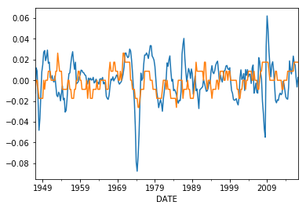

```python
import numpy as np

def rouwen(rho, mu, sigma, num):
#The refernces to the code are below. I changed it slightly,
#so it is similar to lecture slides. Paricularly, I change
#node generating function
    '''
    Adapted from Lu Zhang and Karen Kopecky. Python by Ben Tengelsen.
    Construct transition probability matrix for discretizing an AR(1)
    process. This procedure is from Rouwenhorst (1995), which works
    well for very persistent processes.

    INPUTS:
    rho  - persistence (close to one)
    mu   - mean and the middle point of the discrete state space
    step - step size of the even-spaced grid
    num  - number of grid points on the discretized process

    OUTPUT:
    dscSp  - discrete state space (num by 1 vector)
    transP - transition probability matrix over the grid
    '''

    # discrete state space. Linspace calculates evenly spaced nodes,
    #given start point, end point and the number of iterations
    z_bottom=mu-math.sqrt(num-1)*sigma
    z_top=mu+math.sqrt(num-1)*sigma
    dscSp = np.linspace(z_bottom, z_top, num).T

    # transition probability matrix
    #initalize q and p
    q = p = (rho + 1)/2.

    transP = np.array([[p**2, p*(1-q), (1-q)**2], \
                    [2*p*(1-p), p*q+(1-p)*(1-q), 2*q*(1-q)], \
                    [(1-p)**2, (1-p)*q, q**2]]).T

    while transP.shape[0] <= num - 1:
# transP.shape[0] record the number of rows of a numpy matrix
        # see Rouwenhorst 1995
        len_P = transP.shape[0]
#vstack stacks arrays vertically to make a matrix.
#hstack does the same thing horizontally
#zeros return a 0 matrix of dimensions x,y
        transP = p*np.vstack((np.hstack((transP,np.zeros((len_P,1)))), np.zeros((1, len_P+1)))) \
        + (1-p)*np.vstack((np.hstack((np.zeros((len_P, 1)), transP)), np.zeros((1, len_P+1)))) \
        + (1-q)*np.vstack((np.zeros((1, len_P+1)), np.hstack((transP, np.zeros((len_P, 1)))))) \
        + q*np.vstack((np.zeros((1, len_P+1)), np.hstack((np.zeros((len_P, 1)), transP))))
#Basically vertically stack the following matrix:
#Horizontally stack P(n-1) matrix and 0 column vector
#And row vector of soze P_n. Same applies for other calculations
#normalizeing matrix by diving all but top and bottom columns by 2
        transP[1:-1] /= 2.

    # ensure columns sum to 1
    if np.max(np.abs(np.sum(transP, axis=1) - np.ones(transP.shape))) >= 1e-12:
        print('Problem in rouwen routine!')
        return None
    else:
        return transP.T, dscSp
rho=0.817924
mu=0
num=7
sigma=0.010695029926728373
tauchen_matr,tauchen=rouwen(rho, mu, sigma, num)
tauchen_matr=numpy.transpose(tauchen_matr)
simulation2=simulator(tauchen, tauchen_matr,282)
simulation2=pandas.Series(simulation2,index=bus_cyc.index)
ax = bus_cyc.plot()
simulation2.plot(ax=ax)

#Standard deviation of the process
#Orange is the simulated process
```

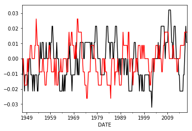

```python
#Tauchen is black line
ax = simulation1.plot(color="black")
simulation2.plot(ax=ax,color="red")
```

Question 2

Rewriting rowen routine defined before so it takes p and q as parameters (not assuming p=q). Determing aautocorrelation of the process:  
$y_t=py_{t-1}+a+\epsilon_t$  
$Cov(y_t,y_{t-1})=Cov(py_{t-1}+a+\epsilon_t,y_{t-1})=pVar(y_t)$

$Corr=p$

```python
from scipy.optimize import root,fsolve
from scipy.stats import skew,kurtosis
def rouwen2(array_of_parameters):
    rho=0.97
    mu=0
    sigma=math.sqrt(0.8)*(math.sqrt(1-rho**2))
    num=9
    p=array_of_parameters[0]
    q=array_of_parameters[1]


    # discrete state space. Linspace calculates evenly spaced nodes,
    #given start point, end point and the number of iterations
    z_bottom=mu-math.sqrt(num-1)*sigma
    z_top=mu+math.sqrt(num-1)*sigma
    dscSp = np.linspace(z_bottom, z_top, num).T

    # transition probability matrix

    transP = np.array([[p**2, p*(1-q), (1-q)**2], \
                    [2*p*(1-p), p*q+(1-p)*(1-q), 2*q*(1-q)], \
                    [(1-p)**2, (1-p)*q, q**2]]).T

    while transP.shape[0] <= num - 1:
# transP.shape[0] record the number of rows of a numpy matrix
        # see Rouwenhorst 1995
        len_P = transP.shape[0]
#vstack stacks arrays vertically to make a matrix.
#hstack does the same thing horizontally
#zeros return a 0 matrix of dimensions x,y
        transP = p*np.vstack((np.hstack((transP,np.zeros((len_P,1)))), np.zeros((1, len_P+1)))) \
        + (1-p)*np.vstack((np.hstack((np.zeros((len_P, 1)), transP)), np.zeros((1, len_P+1)))) \
        + (1-q)*np.vstack((np.zeros((1, len_P+1)), np.hstack((transP, np.zeros((len_P, 1)))))) \
        + q*np.vstack((np.zeros((1, len_P+1)), np.hstack((np.zeros((len_P, 1)), transP))))
#Basically vertically stack the following matrix:
#Horizontally stack P(n-1) matrix and 0 column vector
#And row vector of soze P_n. Same applies for other calculations
#normalizeing matrix by diving all but top and bottom columns by 2
        transP[1:-1] /= 2.

    # ensure columns sum to 1
    if np.max(np.abs(np.sum(transP, axis=1) - np.ones(transP.shape))) >= 1e-12:
        print('Problem in rouwen routine!')
        return None
    else:
        return transP.T, dscSp
def calibrator(array_of_parameters):
    #calculating rouwenhurst matrix and nodes given p and q
    tauchen_matr,tauchen=rouwen2(array_of_parameters)
    tauchen_matr=numpy.transpose(tauchen_matr)
    niter=10500
    #simulating series 10500 times
    simulation3=simulator(tauchen,tauchen_matr,niter)
    #deleting first 500 entries
    simulation=simulation3[500:]
    #Calculating skewness,kurtosis
    skewness=skew(simulation)
    kurtos=kurtosis(simulation)
    #making system of equations equating the moments
    return_array=[skewness+1.1,kurtos-4]
    return(return_array)
#perfroming simple grid-search
for p in np.arange(0,1,0.1):
    for q in np.arange(0,1,0.1):
        print([p,q,calibrator((p,q))])
#The best values are when q=0.9 and p is 0 or 0.1
```

```
[0.0, 0.0, [1.1000000000000008, -6.0]]
[0.0, 0.10000000000000001, [1.0644397979751123, -4.269459518172105]]
[0.0, 0.20000000000000001, [1.0264957733015692, -4.28570796808166]]
[0.0, 0.30000000000000004, [0.973011969727027, -4.1691938735634455]]
[0.0, 0.40000000000000002, [0.923699355522623, -4.244164512033285]]
[0.0, 0.5, [0.8309076462506212, -4.129266641745757]]
[0.0, 0.60000000000000009, [0.8072826000131534, -4.2274836400658975]]
[0.0, 0.70000000000000007, [0.6874339013225356, -4.118753814610007]]
[0.0, 0.80000000000000004, [0.5088472138761775, -3.891428599759359]]
[0.0, 0.90000000000000002, [0.11028806553824633, -3.326318450513482]]
[0.10000000000000001, 0.0, [1.1252548003412304, -4.124460395921158]]
[0.10000000000000001, 0.10000000000000001, [1.1095006453793088, -4.140734173141489]]
[0.10000000000000001, 0.20000000000000001, [1.0767682161357919, -4.283811222651606]]
[0.10000000000000001, 0.30000000000000004, [1.0129065540073587, -4.269513912734121]]
[0.10000000000000001, 0.40000000000000002, [0.9788512164371206, -4.293993154666712]]
[0.10000000000000001, 0.5, [0.8935886822256431, -4.223306017985844]]
[0.10000000000000001, 0.60000000000000009, [0.7842169816227005, -4.145532120225323]]
[0.10000000000000001, 0.70000000000000007, [0.674223211000859, -4.016270371296288]]
[0.10000000000000001, 0.80000000000000004, [0.5167449702653714, -3.882136219479238]]
[0.10000000000000001, 0.90000000000000002, [0.11924425593567844, -3.0566116377060717]]
[0.20000000000000001, 0.0, [1.1800164008152931, -4.231998223818486]]
[0.20000000000000001, 0.10000000000000001, [1.1590188314084018, -4.150405925192079]]
[0.20000000000000001, 0.20000000000000001, [1.1142505337661561, -4.348372163976047]]
[0.20000000000000001, 0.30000000000000004, [1.0661220256183017, -4.265424605172211]]
[0.20000000000000001, 0.40000000000000002, [0.9905034690593183, -4.271910403998705]]
[0.20000000000000001, 0.5, [0.9493287502449335, -4.2475867333777355]]
[0.20000000000000001, 0.60000000000000009, [0.8420334843871953, -4.193027734332242]]
[0.20000000000000001, 0.70000000000000007, [0.7331218365754448, -4.107901073735649]]
[0.20000000000000001, 0.80000000000000004, [0.5825240571956228, -4.001584143207781]]
[0.20000000000000001, 0.90000000000000002, [0.19314161655916473, -3.3262336864233726]]
[0.30000000000000004, 0.0, [1.2394551949573134, -4.231791075697391]]
[0.30000000000000004, 0.10000000000000001, [1.1781326916431087, -4.134012534624761]]
[0.30000000000000004, 0.20000000000000001, [1.1820626928704001, -4.213682718477019]]
[0.30000000000000004, 0.30000000000000004, [1.0724131467253355, -4.259038952943006]]
[0.30000000000000004, 0.40000000000000002, [1.0758804312929569, -4.243239837744188]]
[0.30000000000000004, 0.5, [0.9775941403922471, -4.189597192495862]]
[0.30000000000000004, 0.60000000000000009, [0.8799169743173018, -4.192700374866163]]
[0.30000000000000004, 0.70000000000000007, [0.7851707880428727, -4.10837658337849]]
[0.30000000000000004, 0.80000000000000004, [0.6192351795819284, -4.030685238724486]]
[0.30000000000000004, 0.90000000000000002, [0.34463432473142763, -3.7881027776074276]]
```

[output cut: 45 more lines]

```
[0.80000000000000004, 0.5, [1.4639406523461331, -4.07837329041773]]
[0.80000000000000004, 0.60000000000000009, [1.32532327915443, -4.313524542146428]]
[0.80000000000000004, 0.70000000000000007, [1.2463156744031578, -4.313576196671769]]
[0.80000000000000004, 0.80000000000000004, [1.0756795701634445, -4.177732450079484]]
[0.80000000000000004, 0.90000000000000002, [0.8129536175640295, -4.183920035981562]]
[0.90000000000000002, 0.0, [2.0544482740875973, -3.4845855587633947]]
[0.90000000000000002, 0.10000000000000001, [2.0535574323805728, -3.3764951110102523]]
[0.90000000000000002, 0.20000000000000001, [1.9884815331588035, -3.2438986681579296]]
[0.90000000000000002, 0.30000000000000004, [1.921781851041712, -3.4721036716775684]]
[0.90000000000000002, 0.40000000000000002, [1.793959256611806, -3.8067628327761227]]
[0.90000000000000002, 0.5, [1.6868579529119059, -3.94605076177409]]
[0.90000000000000002, 0.60000000000000009, [1.6234345718760754, -3.9668480234039363]]
[0.90000000000000002, 0.70000000000000007, [1.482364297365446, -4.153764028310649]]
[0.90000000000000002, 0.80000000000000004, [1.3056105136780645, -4.271867798366056]]
[0.90000000000000002, 0.90000000000000002, [1.0369829835728939, -4.2143591820403685]]
```

```python
#narrowing my grid-search
ps=[]
qs=[]
for p in np.arange(0,0.1,0.01):
    for q in np.arange(0.85,0.95,0.01):
        calibr=calibrator((p,q))
        print([p,q,calibr])
        ps.append(abs(calibr[0]))
        qs.append(abs(calibr[1]))
print(min(ps))
print(min(qs))
#min q give -3.1 kurtosis, can do better
#0.03 0.92 does well -0.08 -2.574
```

```
[0.0, 0.84999999999999998, [0.31691881671088695, -3.6336428651924346]]
[0.0, 0.85999999999999999, [0.2837505221494737, -3.6128898874465327]]
[0.0, 0.87, [0.2704744419669617, -3.6578354448550057]]
[0.0, 0.88, [0.22227676630194204, -3.5264236153350685]]
[0.0, 0.89000000000000001, [0.15076434979402809, -3.3724582488310193]]
[0.0, 0.90000000000000002, [0.11863037507770324, -3.370176639519633]]
[0.0, 0.91000000000000003, [0.05130121545370514, -3.1994699884485436]]
[0.0, 0.92000000000000004, [-0.040806467420352543, -3.059459845699189]]
[0.0, 0.93000000000000005, [-0.17890942218739858, -2.5593744814698702]]
[0.0, 0.94000000000000006, [-0.2622130820982136, -2.4650305670175063]]
[0.01, 0.84999999999999998, [0.30130702385207675, -3.551120667742472]]
[0.01, 0.85999999999999999, [0.2354575380260845, -3.3569093036108684]]
[0.01, 0.87, [0.203066403951914, -3.344283142318141]]
[0.01, 0.88, [0.21376496039570703, -3.45972449139973]]
[0.01, 0.89000000000000001, [0.16081963529437493, -3.4641648621552807]]
[0.01, 0.90000000000000002, [0.10575995613096079, -3.054441929517732]]
[0.01, 0.91000000000000003, [0.01405792999027855, -2.9233784654351327]]
[0.01, 0.92000000000000004, [0.026910091132376746, -3.1682465562652533]]
[0.01, 0.93000000000000005, [-0.19243809167430825, -2.5512107117138294]]
[0.01, 0.94000000000000006, [-0.24923167440774407, -2.4398048460541917]]
[0.02, 0.84999999999999998, [0.3609631728047915, -3.7221000101951245]]
[0.02, 0.85999999999999999, [0.27944358454353424, -3.5207901837770295]]
[0.02, 0.87, [0.26521503585811657, -3.436156110601827]]
[0.02, 0.88, [0.22024260439559584, -3.427889929105338]]
[0.02, 0.89000000000000001, [0.15556303227093737, -3.283612343663286]]
[0.02, 0.90000000000000002, [0.0896422191023658, -3.2002948732016936]]
[0.02, 0.91000000000000003, [0.030803321992713517, -3.0887851143832634]]
[0.02, 0.92000000000000004, [-0.0431816620831702, -3.0424436857054906]]
[0.02, 0.93000000000000005, [-0.14809484796950922, -2.640854198934888]]
[0.02, 0.94000000000000006, [-0.2144226392628894, -2.4580580597684873]]
[0.029999999999999999, 0.84999999999999998, [0.3468994949090397, -3.7248689879306527]]
[0.029999999999999999, 0.85999999999999999, [0.29094364735029965, -3.5496812832812257]]
[0.029999999999999999, 0.87, [0.23340924696313103, -3.4944771364650014]]
[0.029999999999999999, 0.88, [0.24516011228938606, -3.5850137228789487]]
[0.029999999999999999, 0.89000000000000001, [0.21704669826415524, -3.493360468369528]]
[0.029999999999999999, 0.90000000000000002, [0.10059003201506389, -3.230974139871858]]
[0.029999999999999999, 0.91000000000000003, [0.03822452050109093, -3.049529335693946]]
[0.029999999999999999, 0.92000000000000004, [-0.08254766933889424, -2.574752150430748]]
[0.029999999999999999, 0.93000000000000005, [-0.12542902807541378, -2.6693569711605605]]
[0.029999999999999999, 0.94000000000000006, [-0.23924943950349387, -2.4394868030901646]]
```

[output cut: 47 more lines]

```
[0.080000000000000002, 0.92000000000000004, [0.028799919467953794, -3.097302161482248]]
[0.080000000000000002, 0.93000000000000005, [-0.10287992541605773, -2.8684172583710543]]
[0.080000000000000002, 0.94000000000000006, [-0.2417774379119515, -2.3626335344367204]]
[0.089999999999999997, 0.84999999999999998, [0.35448163499197216, -3.705560791989002]]
[0.089999999999999997, 0.85999999999999999, [0.304549300992772, -3.543028723831473]]
[0.089999999999999997, 0.87, [0.293081036382033, -3.5270981678674564]]
[0.089999999999999997, 0.88, [0.2481113156379835, -3.5646977825791715]]
[0.089999999999999997, 0.89000000000000001, [0.23565518822929854, -3.596049078018655]]
[0.089999999999999997, 0.90000000000000002, [0.18988756540487373, -3.4548771838179935]]
[0.089999999999999997, 0.91000000000000003, [0.08694301572076513, -3.289971817437301]]
[0.089999999999999997, 0.92000000000000004, [0.021998164957200972, -3.1190252501819327]]
[0.089999999999999997, 0.93000000000000005, [-0.09206778824458173, -2.7563305415733828]]
[0.089999999999999997, 0.94000000000000006, [-0.19839115060999069, -2.6076086706597756]]
0.005897487960248249
2.3626335344367204
```

```python
tauchen_matr,tauchen=rouwen2((0.03,0.92))
tauchen_matr=numpy.transpose(tauchen_matr)
niter=10500
#simulating series 10500 times
simulation4=simulator(tauchen,tauchen_matr,niter)
#deleting first 500 entries
simulation4=simulation4[500:]
#Changing types to use easier difference function
simulation4=np.array(simulation4)
diff_simul=np.diff(simulation4)
print('Standard deviation: %s' % np.std(diff_simul))
print('Skewness %s' % skew(diff_simul))
print('Kurtosis %s' % kurtosis(diff_simul))
```

```
Standard deviation: 0.166814455927
Skewness 0.009397121367452499
Kurtosis 0.36132016293602565
```

The actual values for the parameters are $\sigma=0.51$,$skewness=-1.07$,$kurtosis=15$. My estimates do veeery badly on the moments above.

Part b

The algorithm relies on NMAR proces which is mix of 2 gaussian accuring which occur with different probabilities

Taking screenshots of useful formulas from the original article.

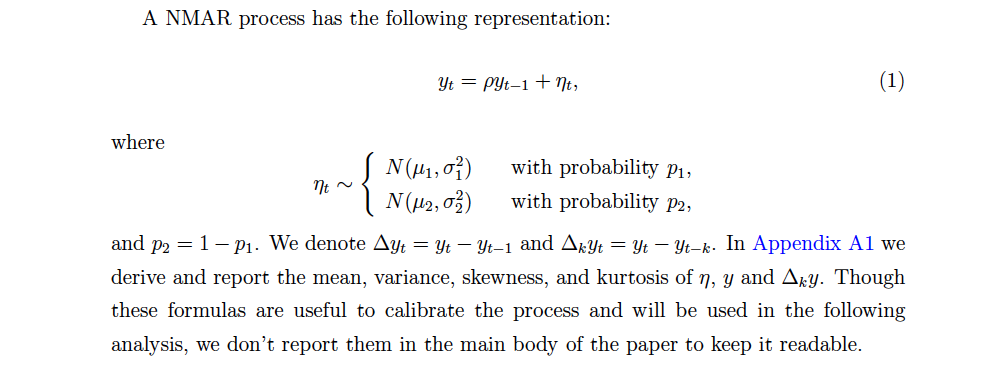

```python
from IPython.display import Image
from IPython.core.display import HTML
Image(filename ="NMAR.png", width=500, height=500)
```

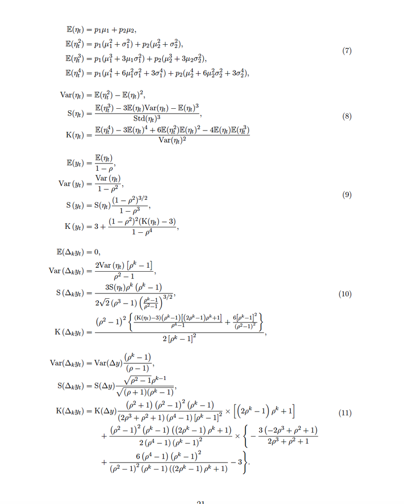

```python
Image(filename ="DistroMom.png", width=500, height=500)
```

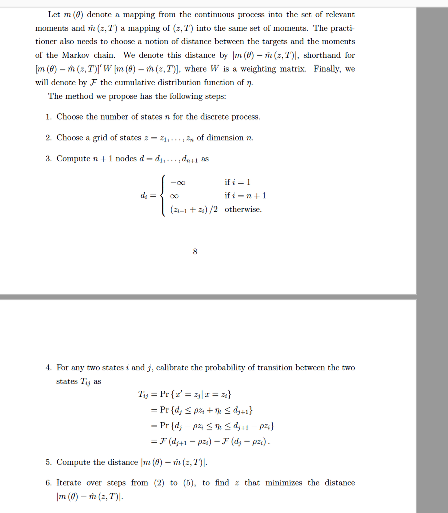

```python
Image(filename ="ExtTauch.png", width=500, height=500)
```

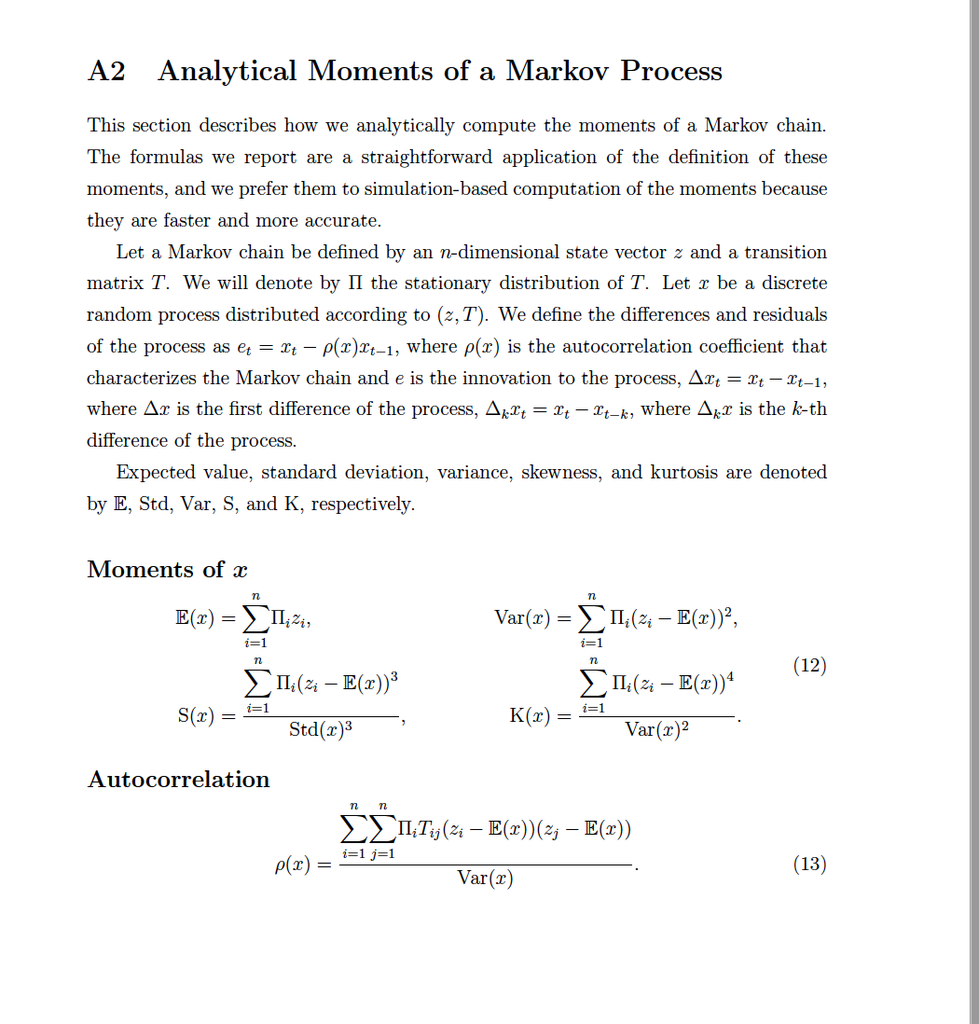

```python
Image(filename ="Markov1.png", width=500, height=500)
```

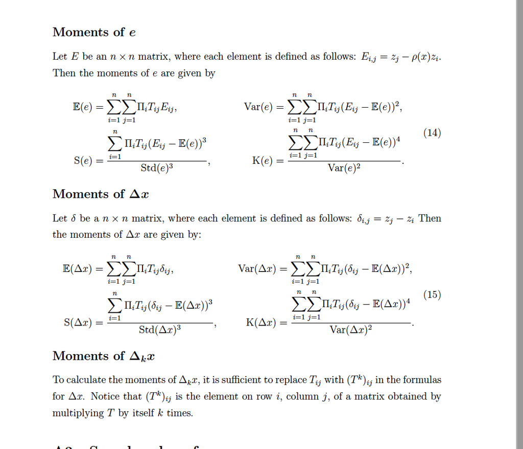

```python
Image(filename ="Markov2.png", width=500, height=500)
```

My general algorthm:  
1) Use Distributional moments to calculate approximations to initial values of distributional parameters using a minimization routine

2) Write the Extended Tauchen routine

3) Set initial z to those used in Rowenhurst

3) Program analytical markov chain moments

4) Use minimization techniques, such as polytope to solve for distributional parameters and for z

```python
import math
from scipy.stats import norm
from discreteMarkovChain import markovChain
# 1) Coding the distribution of Extended Tauchen distrubance term
#Which is used in Extended Tauchen
def norm_cdf(stddev,mean,x):
    dist=norm(scale=stddev,loc=mean)
    return(dist.cdf(x))
def nu_cdf(array_of_distr_params,value):
    mix_prob=array_of_distr_params[0]
    mix_prob2=1-mix_prob
    mean1=array_of_distr_params[1]
    mean2=array_of_distr_params[2]
    std1=array_of_distr_params[3]
    std2=array_of_distr_params[4]
    p=mix_prob
    norm_cdf1=norm_cdf(std1,mean1,value)
    norm_cdf2=norm_cdf(std2,mean2,value)
#I think code is self-explanatory
    result=p*norm_cdf1+(1-p)*norm_cdf2
    return(result)
#Calculate approximations of distributional parameters:
#8 equations 5 unknows, let`s see how well I will do...
def proxima_distr(array_of_distr_params,autocorr1):
#coding autocorrelation directly, as don`t want to mess with it
    autocorr=autocorr1
#taking other 5 parameters as inputs to minimization routine
    mix_prob=array_of_distr_params[0]
    mix_prob2=1-mix_prob
    gaus_mean_1=array_of_distr_params[1]
    gaus_mean_2=array_of_distr_params[2]
    gaus_var_1=array_of_distr_params[3]
    gaus_var_2=array_of_distr_params[4]
#Coding moments as in the first image
#Coding moments of diturbance process which will
#be used to calculate
    mean_nu=mix_prob*gaus_mean_1+mix_prob2*gaus_mean_2
    var_nu=mix_prob*(gaus_mean_1**2+gaus_var_1**2)+ \
    mix_prob2*(gaus_mean_2**2+gaus_var_2**2)
    skew_nu=mix_prob*(gaus_mean_1**3+3*gaus_mean_1*gaus_var_1**2)+ \
    mix_prob2*(gaus_mean_2**3+3*gaus_mean_2*gaus_var_2**2)
#This is normal kurtosis (without substracting 3)
    kurtosis_nu=mix_prob*(gaus_mean_1**4+6*(gaus_mean_1**2)* \
    (gaus_var_1**2)+3*(gaus_var_1**4))+ \
    mix_prob2*(gaus_mean_2**4+6*(gaus_mean_2**2)* \
    (gaus_var_2**2)+3*(gaus_var_2**4))
#Calculating moments of the process
    mean_y=mean_nu/(1-autocorr)
    var_y=var_nu/(1-autocorr**2)
    skew_y=skew_nu*((1-autocorr**2)**(3/2))/(1-autocorr**3)
#This is excess kurtosis
    kurtosis_y=((1-autocorr**2)**2)*(kurtosis_nu-3)/(1-autocorr**4)
#Calculating moments of the difference
    k=1
    diff_mean_y=0
    diff_var_y=2*var_nu*((autocorr**k)-1)/((autocorr**2)-1)
    diff_skew_y=3*skew_nu*((autocorr**k))*((autocorr**k)-1)/ \
    ((2**(3/2))*((autocorr**3)-1)* \
    (((autocorr**k-1)/(autocorr**2-1))**(3/2)))
    #splitted the formula to decrease my margin for mistake
    big_weird_thing=((kurtosis_nu-3)*(autocorr**k-1)* \
    ((2*autocorr**k-1)*(autocorr**k)+1))/ \
    (autocorr**4-1)+6*((autocorr**k-1)**2)/((autocorr**2-1)**2)
    diff_kurtosis_y=(((autocorr**2-1)**2)*big_weird_thing/ \
                     (2*((autocorr**k-1)**2)))-3
    #returing_the parameters
    return([mean_y,var_y,skew_y,kurtosis_y,diff_mean_y,
           diff_var_y,diff_skew_y,diff_kurtosis_y])

#---------------------------------
#function that does double sums as required
def double_sum(vector,matrix1,matrix2,mean,power):
#Find dimensions of a numpy matrix
    result=0
    dimensions=matrix1.shape
    for i in range(0,dimensions[0]):
        for j in range(0,dimensions[1]):
            result+=vector[i]*matrix1[i,j]*pow((matrix2[i,j]-mean),power)
    return(result)
def autocor_sum(vector,matrix1,vector2):
    result=0
    dimensions=matrix1.shape
    for i in range(0,dimensions[0]):
        for j in range(0,dimensions[1]):
            result+=vector[i]*matrix1[i,j]*vector2[i]*vector2[j]
    return(result)

def delta_matrix(vector_of_z):
    output_matrix=[]
    for i in range(0,len(vector_of_z)):
        row=[]
        for j in range(0,len(vector_of_z)):
            row.append(vector_of_z[j]-vector_of_z[i])
        output_matrix.append(row)
    output_matrix=numpy.array(output_matrix)
    assert output_matrix.shape[0]==len(vector_of_z) and \
    output_matrix.shape[1]==len(vector_of_z)
    return(output_matrix)
#Moment calculating function from the transition_matrix
def moment_calculating(transition_matrix,z_s):
#calculating stationary distribution of the transition_matrix
#I am using discreteMarkovChain package to do that
#transition matrix must be numpy array
    mc = markovChain(transition_matrix)
    mc.computePi('linear') #We can also use 'power', 'krylov' or 'eigen'
    stat_distro=mc.pi
#use numpy.dot for dot product
    mean_x=numpy.dot(stat_distro,z_s)
    var_x=numpy.dot(stat_distro,pow((z_s-mean_x),2))
    skew_x=numpy.dot(stat_distro,pow((z_s-mean_x),3))/(var_x**(3/2))
    kurtosis_x=-3+numpy.dot(stat_distro,pow((z_s-mean_x),4))/(var_x**(2))
    delta=delta_matrix(z_s)
    autocorr_x=autocor_sum(stat_distro,transition_matrix, \
        z_s-mean_x)/var_x
    mean_diff_x=double_sum(stat_distro,transition_matrix,delta,0,1)
    var_diff_x=double_sum(stat_distro,transition_matrix,
                          delta,mean_diff_x,2)
    skew_diff_x=double_sum(stat_distro,transition_matrix,
        delta,mean_diff_x,3)/pow(var_diff_x,3/2)
    kurtosis_diff_x=-3+double_sum(stat_distro,transition_matrix,
        delta,mean_diff_x,4)/pow(var_diff_x,2)
    return([mean_x,var_x,skew_x,kurtosis_x,autocorr_x,
           mean_diff_x,var_diff_x,skew_diff_x,kurtosis_diff_x])



#-------------------------------
def rowenhurst_nodes(num,mu,sigma):
    z_bottom=mu-math.sqrt(num-1)*sigma
    z_top=mu+math.sqrt(num-1)*sigma
    dscSp = numpy.linspace(z_bottom, z_top, num).T
    return(dscSp)
#Tauchen method
def extended_tauchen_trans_matrix(array_of_distr_params,number_of_states,
                                  dscSp,autocorr):
    #making nodes as described in step 3
    test = math.inf
    midpoints=[-test]
    for i in range(1,number_of_states):
        midpoints.append((dscSp[i]-dscSp[i]-1)/2)
    midpoints.append(test)
    #step 4. Calculating transition matrix
    trans_matr=[]
    for i in range(0,len(dscSp)):
        row=[]
        for j in range(0,len(dscSp)):
            value_to_append=nu_cdf(array_of_distr_params,midpoints[j+1]-
            autocorr*dscSp[i])- \
            nu_cdf(array_of_distr_params,midpoints[j]-autocorr*dscSp[i])
            row.append(value_to_append)
        trans_matr.append(row)
    return(trans_matr)
```

Approximating initial values of distributional parameters ()irrelevant

```python
from scipy.optimize import minimize, fsolve
def convert_ls(array_of_distr_params,target_values,autocorr1):
    mean_y=target_values[0]
    var_y=target_values[1]
    skew_y=target_values[2]
    kurtosis_y=target_values[3]
    diff_mean_y=target_values[4]
    diff_var_y=target_values[5]
    diff_skew_y=target_values[6]
    diff_kurtosis_y=target_values[7]
    target_values2=numpy.array([mean_y,var_y,skew_y,kurtosis_y,diff_mean_y,
           diff_var_y,diff_skew_y,diff_kurtosis_y])
    target_values2=target_values2[0:4]
    results=numpy.array(proxima_distr(array_of_distr_params,autocorr1))
    results=results[0:4]
    differences=results-target_values2
    sum_squares=0
    weights=[1,1,1,1,1,1,1,1,1,1,1,1,1]
    for i in range(0,len(differences)):
        if target_values2[i]!=0:
            sum_squares+=weights[i]*abs(differences[i]/target_values2[i])
        else:
            sum_squares+=weights[i]*abs(differences[i])
    return(sum_squares)
target_values=[0,0.8,-1.1,4,0,0.51**2,-1.07,15]
autocorr1=0.97
def to_minimize1(array_of_distr_params):
    mix_prob=array_of_distr_params[0]
    gaus_mean_1=array_of_distr_params[1]
    gaus_mean_2=array_of_distr_params[2]
    gaus_var_1=array_of_distr_params[3]
    gaus_var_2=array_of_distr_params[4]
    if mix_prob>1 or mix_prob<0:
        return(99999999)
    if gaus_var_1<0 or gaus_var_2<0:
        return(99999999)
    return convert_ls(array_of_distr_params,target_values,autocorr1)
#distributional parameters are probability,mean1,mean2,std1,std2
distro1=uniform(0,1)
distro2=uniform(-10,10)
distro3=uniform(-10,10)
distro4=uniform(0,5)
distro5=uniform(0,5)
x0=numpy.array([distro1,distro2,distro3,distro4,distro5])
#print(fsolve(to_minimize1,x0))
argmin=minimize(to_minimize1,x0,method='Powell',
              options={"maxiter": 10000, "maxfev":10000000})
print(argmin)
print(numpy.array(proxima_distr(argmin.x,autocorr1))[0:4])
#print(to_minimize1(x0))
#Unfortunately, values are not very meaningfull
#x3=numpy.array([])
#print(proxima_distr(x3,autocorr1))
```

```
   direc: array([[ 1.,  0.,  0.,  0.,  0.],
       [ 0.,  1.,  0.,  0.,  0.],
       [ 0.,  0.,  1.,  0.,  0.],
       [ 0.,  0.,  0.,  1.,  0.],
       [ 0.,  0.,  0.,  0.,  1.]])
     fun: 2.0011264965761404
 message: 'Optimization terminated successfully.'
    nfev: 518
     nit: 4
  status: 0
 success: True
       x: array([  9.98097659e-01,   1.89741918e-03,  -9.95515131e-01,
         1.37716176e-01,   3.72960106e+00])
[ -6.75138772e-10   8.00000000e-01  -1.32932075e-02  -5.28449200e-02]
```

My experience with trying to calculate distributional parameters is that I can only perfectly match 2 moments with my 5 parameters. In the output above, I found perfect fit for mean and standard deviation, however skewnes and kurtosis are of standard normal distribution. If one looks at the estimated parameters, the chosen mixing probability (the first thing in the x array) is almost 1. The NMAR process basically almost converges to standard normal

Calculating the Extended Tauchen Approximation

```python
import time
def convert2_ls(array_of_distr_params,autocorra,
               target_values,z_s,number_of_states):
#calculating transition matrix given initial vector of states z
    transition_matrix=extended_tauchen_trans_matrix(array_of_distr_params,
                            number_of_states,z_s,autocorra)
    transition_matrix=numpy.array(transition_matrix)
#    print(transition_matrix)
#    print(transition_matrix.shape)
    estimated_moments=numpy.array(
    moment_calculating(transition_matrix,z_s))
#    return([mean_x,var_x,skew_x,kurtosis_x,autocorr_x,
#           mean_diff_x,var_diff_x,skew_diff_x,kurtosis_diff_x])
#specifying what is what
    mean_y=target_values[0]
    var_y=target_values[1]
    skew_y=target_values[2]
    kurtosis_y=target_values[3]
    autocorr_y=target_values[4]
    diff_mean_y=target_values[5]
    diff_var_y=target_values[6]
    diff_skew_y=target_values[7]
    diff_kurtosis_y=target_values[8]
#just so i don`t forget
    target_values2=numpy.array([mean_y,var_y,skew_y,kurtosis_y,
    autocorr_y,diff_mean_y,diff_var_y,diff_skew_y,diff_kurtosis_y])
    differences=estimated_moments-target_values2
    sum_squares=0
    mix_prob=array_of_distr_params[0]
    gaus_var_1=array_of_distr_params[3]
    gaus_var_2=array_of_distr_params[4]
#ensuring meaningful mixing probability and non-negative variance
    if mix_prob>1 or mix_prob<0:
        return(99999999)
    if gaus_var_1<0 or gaus_var_2<0:
        return(99999999)
#calculating the sum of squares
    for i in range(0,len(differences)):
        if target_values2[i]!=0:
            sum_squares+=abs(differences[i]/target_values2[i])
        else:
            sum_squares+=abs(differences[i])*10000
    return(sum_squares)
#setting initial value and target values and number of states
distro_params=numpy.array([0.8,-10,5,10,0.2])
autocorr1=numpy.array([0.97])
target_values=numpy.array([0,0.8,-1.1,4,0.97,0,0.51**2,-1.07,15])
number_of_states=7
#initial value
starting_nodes=rowenhurst_nodes(number_of_states,0,math.sqrt(0.97))
#print(starting_nodes)
x0=numpy.concatenate([distro_params,autocorr1,starting_nodes])
def to_minimize2(array_of_params):
    array_of_distr_params=array_of_params[0:5]
#    print(array_of_distr_params)
    autocorra=array_of_params[5]
#    print(autocorra)
    z_s=array_of_params[6:(6+number_of_states)]
#    print(z_s)
    return convert2_ls(array_of_distr_params,autocorra,
               target_values,z_s,number_of_states)
#print(to_minimize2(x0))
start_time=time.time()
carma=minimize(to_minimize2,x0,method='Powell',
               options={"maxiter": 10000, "maxfev":10000000})
end_time=time.time()
print(end_time-start_time)
#My distriubtional parameter is standard deviation not variance
#Rewrite everything in standard deviations, so no negative variance problem.
```

```
106.80083084106445
```

```python
print(carma)
```

[output not shown]

[output cut: 29 more lines]

```
          2.57734617e+00]]), array([ 53.52224855,  53.52225145,  53.52226054,  53.52226386,
        53.52226612,  53.5222694 ,  53.52227231,  53.52227598,
        53.52227656,  53.52228288,  53.52228911,  53.52228962,
        53.52229742,  53.5223019 ]))
           fun: 53.522248551381509
       message: 'Optimization terminated successfully.'
          nfev: 639
           nit: 337
        status: 0
       success: True
             x: array([  6.52515223e-01,  -9.86393589e+00,   5.19422496e+00,
         1.06176077e+01,   2.06625657e-01,   9.71480914e-01,
        -2.32828760e+00,  -1.64803399e+00,  -8.17950001e-01,
         4.67007067e-05,   8.21086567e-01,   1.63052074e+00,
         2.57734613e+00])
```

```python
array_of_params=carma.x
number_of_states=7
array_of_distr_params=array_of_params[0:5]
#    print(array_of_distr_params)
autocorra=array_of_params[5]
#    print(autocorra)
z_s=array_of_params[6:(6+number_of_states)]
transition_matrix=extended_tauchen_trans_matrix(array_of_distr_params,
                            number_of_states,z_s,autocorra)
transition_matrix=numpy.array(transition_matrix)
#    print(transition_matrix)
#    print(transition_matrix.shape)
estimated_moments=numpy.array(
    moment_calculating(transition_matrix,z_s))
```

Here for that one iteration, you can compare target values with those estimated.  
I specifically set targets to set means to zero. This process ridiculously badly matches autocorrelation, excess skewnes of y process, skewness is almost zero for both differences and the actial process. Standard deviations are over predicted.

```python
print(estimated_moments)
target_values=numpy.array([0,0.8,-1.1,4,0.97,0,0.51**2,-1.07,15])
#    return([mean_x,var_x,skew_x,kurtosis_x,autocorr_x,
#           mean_diff_x,var_diff_x,skew_diff_x,kurtosis_diff_x])
```

```
[ -1.07987317e-08   6.00080302e+00   1.01670924e-01  -1.98966302e+00
   7.98272777e-02  -2.22044605e-16   1.10435505e+01   7.31333978e-50
  -8.20878146e-01]
```

Running a loop which randomly generates inital values to avoid local minima

```python
from numpy.random import uniform
#Randomiser
array_of_results=[]
distro_params=numpy.array([0.5,-1,1,1,3])
number_of_states=9
starting_nodes=rowenhurst_nodes(number_of_states,0,math.sqrt(0.97))
start_time=time.time()
for i in range(0,140):
    distro1=uniform(0,1)
    distro2=uniform(-10,10)
    distro3=uniform(-10,10)
    distro4=uniform(0,5)
    distro5=uniform(0,5)
    distro_params=numpy.array([distro1,distro2,distro3,distro4,distro5])
    x0=numpy.concatenate([distro_params,autocorr1,starting_nodes])
    array_of_results.append(minimize(to_minimize2,x0,method='Powell', options={"maxiter": 10000, "maxfev":10000000}))
end_time=time.time()
print(end_time-start_time)
```

[output not shown]

[output cut: 88 more lines]

[output not shown]

Printing output. First row value of penalty function. Second row argmin, with first 5 being NMAR process distributional parameters, then autocorrelation, the z_s. 3-rd is estimated moments. 4-th is approximate distribution of the NMAR process (not markov chain) given the parameters.

```python
for i in array_of_results:
    print(i.fun)
    print(i.x)
    array_of_params=i.x
    array_of_distr_params=array_of_params[0:5]
#    print(array_of_distr_params)
    autocorra=array_of_params[5]
#    print(autocorra)
    z_s=array_of_params[6:(6+number_of_states)]
    transition_matrix=extended_tauchen_trans_matrix(array_of_distr_params,
                            number_of_states,z_s,autocorra)
    transition_matrix=numpy.array(transition_matrix)
#    print(transition_matrix)
#    print(transition_matrix.shape)
    estimated_moments=numpy.array(
        moment_calculating(transition_matrix,z_s))
    print(estimated_moments)
    print(proxima_distr(array_of_distr_params,autocorra))
```

16.0384445144

[ 2.17011098e-04 4.62354392e+01 -5.02142803e-01 7.25976662e+00 1.47520632e+00 9.69303858e-01 -2.78567767e+00 3.08659968e+00 3.78301910e+00 4.47943851e+00 5.17585792e+00 5.87227734e+00 6.56869675e+00 7.26511616e+00 2.78567766e+00]

[ -8.65973959e-14 7.76000004e+00 -5.70516163e-09 -2.00000000e+00 9.32602117e-01 -5.55111512e-17 1.04601516e+00 -1.66044023e-15 2.66745224e+01]

[-16.02808035839745, 48.02643643271611, 3.2676559367803173, 35.990811953757557, 0, 2.9484526147987813, 19.174790496694598, 1119.605060521576]  
This is one of the best results. The NMAR process chosen was basically just a normal distribution. While autocorrelation parameter was correctly unchanged from initial value of 0.97, the discrete approximation has value of autocorrelation of 0.93. The distiribution of NMAR is completely off. This is because moments are divided by $(1-autocorrelation)$, implying that small deviations are severely magnified. The discretized distribution does well on means and autocorrelations because I specified penalty function this way, but severely exagarates standard deviations. Skewness is essentially zero in both levels and differences. Kurtosis in level is smaller even than that of normal while in levels is severely exagaratted.

# Conclusion

Because of the persistance of the process, NMAR process has very low power to fit all the moments of the distributions. Slight deviations of actual values are magnified by autocorrelation. As a result, the extended tauchen procedure itself suffers a lot, being able to match only 3 out of 9 specified moment conditions.  
Essentially there are 3 possibilities:

1) Extended Tauchen methods is not able to to discretize high-persistancy AR(1) process  
2) The data iteslf is not AR(1) and can not be generated by AR(1) process  
3) My code is wrong